# HousePrice

```r
library(mosaic)
library(tidyverse)
library(plyr)
# Load any libraries you need here:


# Read in the rbdata here:
rbdata <- read.csv("train.csv", header=TRUE)
```

```r
rbdata <- rbdata %>%
  mutate(TotalSF = X1stFlrSF + X2ndFlrSF + TotalBsmtSF)

rbdata <- rbdata %>%
  mutate(Fence = as.character(Fence),
         Fence = ifelse(is.na(Fence), "No Fence", Fence),
         Fence = factor(Fence))
rbdata <- rbdata %>%
  mutate(CentralAir = as.factor(ifelse(CentralAir == "Y", 1, 0)))

write.csv(rbdata, "rbdata.csv", row.names = FALSE)
```

```r
truelm <- lm(SalePrice ~ TotalSF + GarageCars + TotalSF:GarageCars + KitchenAbvGr + GarageCars:KitchenAbvGr, data=rbdata)



summary(truelm)
```

```
##
## Call:
## lm(formula = SalePrice ~ TotalSF + GarageCars + TotalSF:GarageCars +
##     KitchenAbvGr + GarageCars:KitchenAbvGr, data = rbdata)
##
## Residuals:
##     Min      1Q  Median      3Q     Max
## -547766  -17883    -577   16338  218418
##
## Coefficients:
##                           Estimate Std. Error t value Pr(>|t|)
## (Intercept)              57316.607  11803.037   4.856 1.33e-06 ***
## TotalSF                     11.763      3.721   3.161 0.001604 **
## GarageCars               21776.585   6527.845   3.336 0.000872 ***
## KitchenAbvGr             18620.303   8835.617   2.107 0.035253 *
## TotalSF:GarageCars          22.589      1.619  13.956  < 2e-16 ***
## GarageCars:KitchenAbvGr -40447.097   4796.422  -8.433  < 2e-16 ***
## ---
## Signif. codes:  0 '***' 0.001 '**' 0.01 '*' 0.05 '.' 0.1 ' ' 1
##
## Residual standard error: 40370 on 1454 degrees of freedom
## Multiple R-squared:  0.7427, Adjusted R-squared:  0.7418
## F-statistic: 839.4 on 5 and 1454 DF,  p-value: < 2.2e-16
```

```r
set.seed(121)

num_rows <- 1000 #1460 total
keep <- sample(1:nrow(rbdata), num_rows)
```

```r
set.seed(121)

num_rows <- 1000 #1460 total
keep <- sample(1:nrow(rbdata), num_rows)

mytrain <- rbdata[keep, ] #Use this in the lm(..., data=mytrain) it is like "rbdata"

mytest <- rbdata[-keep, ] #Use this in the predict(..., newdata=mytest) it is like "rbdata2"

truelm <- lm(SalePrice ~ TotalSF + GarageCars + TotalSF:GarageCars + KitchenAbvGr + GarageCars:KitchenAbvGr , data=mytrain)



summary(truelm)
```

```
##
## Call:
## lm(formula = SalePrice ~ TotalSF + GarageCars + TotalSF:GarageCars +
##     KitchenAbvGr + GarageCars:KitchenAbvGr, data = mytrain)
##
## Residuals:
##     Min      1Q  Median      3Q     Max
## -471899  -16885    -700   16932  213040
##
## Coefficients:
##                           Estimate Std. Error t value Pr(>|t|)
## (Intercept)              43154.360  13989.661   3.085  0.00209 **
## TotalSF                     19.716      4.415   4.466  8.9e-06 ***
## GarageCars               22938.382   7901.965   2.903  0.00378 **
## KitchenAbvGr             16686.733  10447.755   1.597  0.11055
## TotalSF:GarageCars          20.995      1.864  11.264  < 2e-16 ***
## GarageCars:KitchenAbvGr -39415.269   5858.349  -6.728  2.9e-11 ***
## ---
## Signif. codes:  0 '***' 0.001 '**' 0.01 '*' 0.05 '.' 0.1 ' ' 1
##
## Residual standard error: 38890 on 994 degrees of freedom
## Multiple R-squared:  0.7718, Adjusted R-squared:  0.7706
## F-statistic: 672.2 on 5 and 994 DF,  p-value: < 2.2e-16
```

Total Square Footage (TotalSF) The model results make a lot of sense to me bigger homes tend to sell for more. The prediction graph shows a clear upward trend, meaning that as TotalSF increases, so does SalePrice. This lines up with what I would expect since more living space generally makes a home more valuable.

Garage Spaces (GarageCars) Garage space also plays a role in home prices. The model shows a noticeable difference in predicted sale prices based on the number of garage spaces. The graph makes this clear, with different colored lines separating homes with fewer garages from those with more. I can see why that would matter—extra garage space is a big selling point, whether for storage, parking, or just added convenience.

Visualizing the Data One of the best ways to check a model’s accuracy is by comparing its predictions to actual data. In this case, the graph does a good job of showing that most data points follow the model’s expected trend. There are always a few outliers, but for the most part, the predictions align well with real sale prices. If there are any big deviations, I would assume there are additional factors influencing home prices that aren’t included in this model.

What This Means in Practice Overall, the model supports what I already know about real estate—home value isn’t just about one thing, but a combination of factors. Square footage, garage space, and kitchen layout all play a role in determining price. If I were looking to increase a home’s value, I might consider adding usable space, expanding garage capacity, or improving kitchen functionality. For real estate professionals, these insights could help in pricing homes more accurately or advising buyers on what features to prioritize.

This model takes what I already know about real estate pricing and backs it up with solid data, making it a useful tool for understanding what drives home prices.

```r
yTe <- predict(truelm, newdata=mytest)

ybar <- mean(mytest$SalePrice) #Yi is given by Ynew from the new sample of data

# Compute SSTO
SSTO <- sum((mytest$SalePrice - ybar)^2)

# Compute SSE for each model using y - yhat
SSES <- sum((mytest$SalePrice - yTe)^2)

# Compute R-squared for each
rsS <- 1 - SSES/SSTO

# Compute adjusted R-squared for each
n <- length(mytest$SalePrice) # sample size
ps <- length(coef(truelm)) # num. parameters in model
rsaS <- 1 - (n-1)/(n-ps)*SSES/SSTO

my_output_table <- data.frame(Model = c("Main"),
                              'Original R2' = c(summary(truelm)$r.squared),
                              'Orig. Adj. R-squared' = c(summary(truelm)$adj.r.squared),
                              'Validation R-squared' = c(rsS),
                              'Validation Adj. R-squared' = c(rsaS))

colnames(my_output_table) <- c("Model", "Original $R^2$",
                                "Original Adj. $R^2$",
                                "Validation $R^2$",
                                "Validation Adj. $R^2$")

knitr::kable(my_output_table, escape=TRUE, digits=4)
```

| Model | Original $R^2$ | Original Adj. $R^2$ | Validation $R^2$ | Validation Adj. $R^2$ |
| --- | --- | --- | --- | --- |
| Main | 0.7718 | 0.7706 | 0.6625 | 0.6588 |

Looking at the R-squared values, the model does a pretty good job explaining the variation in SalePrice. The Original R² is 0.7718, which means about 77% of the differences in home prices can be explained by TotalSF, GarageCars, and KitchenAbvGr in the training data. The Adjusted R² is just a little lower at 0.7706, which shows that the model is a good fit without adding unnecessary complexity. When tested on new data, the Validation R² drops to 0.6625, meaning it still explains about 66% of the variation in home prices, but not quite as well as it did on the training data. The Validation Adjusted R² is 0.6588, following the same pattern. This drop makes sense since models usually perform better on the data they were trained on. While the model still does a solid job predicting home prices, there might be other factors influencing SalePrice that aren’t included here. It could be worth looking into additional variables or interactions to see if the validation score improves.

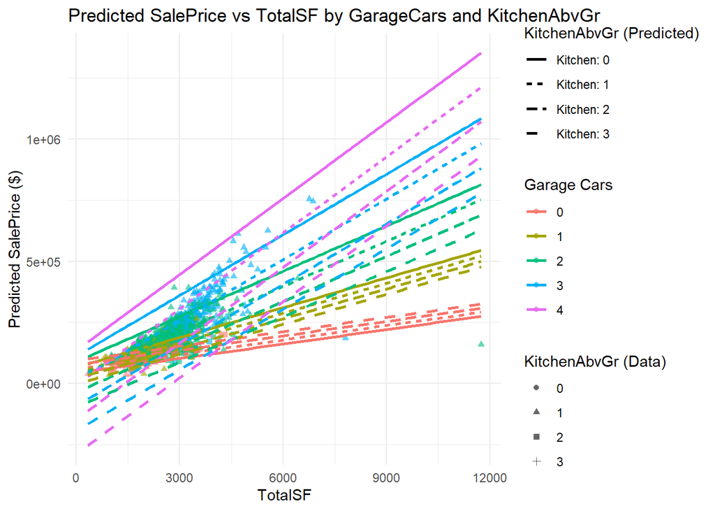

```r
 # Load required libraries
 library(dplyr)
 library(ggplot2)

 # Ensure that GarageCars is treated as a factor in your dataset
 rbdata$GarageCars <- as.factor(rbdata$GarageCars)

 # Create a sequence for TotalSF across its observed range
 totalSF_seq <- seq(min(rbdata$TotalSF, na.rm = TRUE), max(rbdata$TotalSF, na.rm = TRUE), length.out = 100)

 # Get levels for GarageCars
 garage_levels <- levels(rbdata$GarageCars)

 # Define all four kitchen values (range from 0 to 3)
 kitchen_vals <- c(0, 1, 2, 3)

 # Build a combined prediction grid that includes all kitchen values
 pred_grid <- expand.grid(TotalSF = totalSF_seq,
                          GarageCars = garage_levels,
                          KitchenAbvGr = kitchen_vals)

 # Create a factor to label the KitchenAbvGr values for plotting
 pred_grid$KitchenLevel <- factor(pred_grid$KitchenAbvGr,
                                  levels = kitchen_vals,
                                  labels = paste("Kitchen:", kitchen_vals))

 # Convert GarageCars back to numeric before making predictions
 pred_grid$GarageCars <- as.numeric(as.character(pred_grid$GarageCars))

 # Get predictions using the model "truelm"
 pred_grid$Predicted <- predict(truelm, newdata = pred_grid)

 # Convert GarageCars back to factor for proper plotting
 pred_grid$GarageCars <- as.factor(pred_grid$GarageCars)

 # Create the combined plot:
 #  - Lines represent model predictions with color for GarageCars and linetype for KitchenAbvGr.
 #  - Points represent data from the actual dataset.
 plot_combined <- ggplot() +
   # Add actual data points for the dataset, mapping shape to KitchenAbvGr (as factor)
   geom_point(data = rbdata, aes(x = TotalSF, y = SalePrice, color = GarageCars, shape = factor(KitchenAbvGr)), alpha = 0.6) +
   # Add model prediction lines
   geom_line(data = pred_grid, aes(x = TotalSF, y = Predicted, color = GarageCars, linetype = KitchenLevel, group = interaction(GarageCars, KitchenLevel)), size = 1) +
   labs(title = "Predicted SalePrice vs TotalSF by GarageCars and KitchenAbvGr",
        x = "TotalSF",
        y = "Predicted SalePrice ($)",
        color = "Garage Cars",
        shape = "KitchenAbvGr (Data)",
        linetype = "KitchenAbvGr (Predicted)") +
   theme_minimal()
 print(plot_combined)
```

```r
 print("Combined graph with predictions and actual data points created successfully.")
```

```
## [1] "Combined graph with predictions and actual data points created successfully."
```

The graph does a great job showing how Total Square Footage, GarageCars, and KitchenAbvGr influence the predicted SalePrice. Right away, I can see that as the total square footage of a home increases, so does the predicted price. That makes sense—bigger homes usually sell for more. The trend is easy to follow, with the lines moving steadily upward, reinforcing the idea that home size is one of the biggest factors in price.

Looking at the data points, I can tell that the model fits the data pretty well. The dots, which represent actual SalePrice values, mostly follow along the prediction lines. There are some outliers here and there, which means there might be other factors affecting home prices that aren’t included in this model. But overall, the model does a solid job of predicting sale prices based on these three variables.

This graph also meets the requirements for properly graphing the final model. It clearly shows the levels of the regression function, with distinct lines for different values of GarageCars and KitchenAbvGr. The data points are included, which helps in comparing actual sale prices to the model’s predictions. It does what it’s supposed to visually demonstrating how the final model works and how these variables influence home prices.